# NYPD Project

### Visualization 2

#### Question:Are women more likely to became the victims?

#### Visualization:

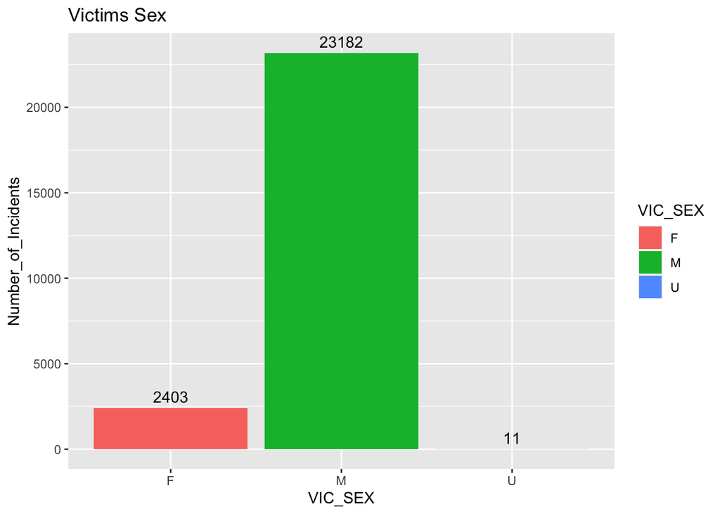

```r
#create a new data frame called nypddata_by_vic_sex
nypddata_by_vic_sex<-nypddata %>%
  group_by(VIC_SEX) %>%
  summarise(count = n()) %>%
  rename('Number_of_Incidents'='count')

nypddata_by_vic_sex %>%
  ggplot(aes(x=VIC_SEX,y=Number_of_Incidents,fill = VIC_SEX))+
  geom_bar(stat = "identity") +
  geom_text(aes(label = Number_of_Incidents), vjust = -0.5)+
  labs(title="Victims Sex")
```

What about the sex of perpetrators?

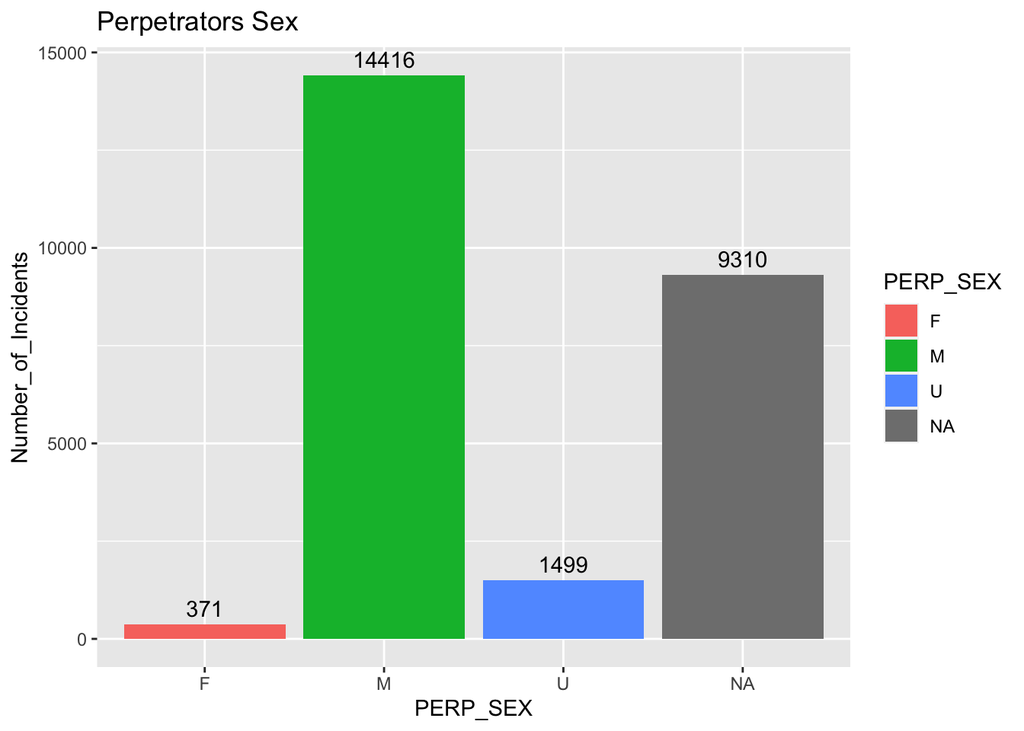

```r
nypddata_by_perp_sex<-nypddata %>%
  group_by(PERP_SEX) %>%
  summarise(count = n()) %>%
  rename('Number_of_Incidents'='count')

nypddata_by_perp_sex %>%
  ggplot(aes(x=PERP_SEX,y=Number_of_Incidents,fill = PERP_SEX))+
  geom_bar(stat = "identity") +
  geom_text(aes(label = Number_of_Incidents), vjust = -0.5)+
  labs(title="Perpetrators Sex")
```

#### Analysis:

Most of the victims and perpetrator are male. There is a significant difference between the number of males and females got involved into the shooting incidents.

### Visualization 3

#### Questions: What about the age group? Are young people more likely to get involved in the incidences?

#### Visualization:

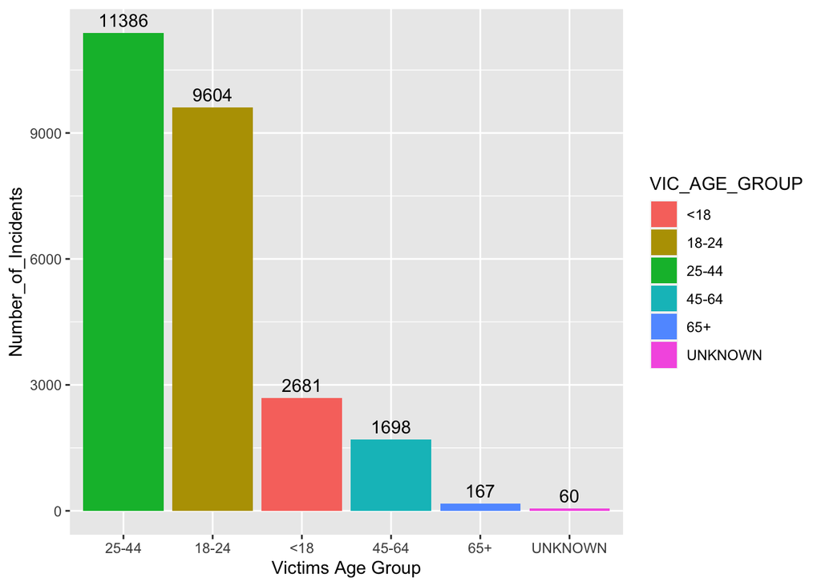

```r
nypddata_by_vic_age<-nypddata %>%
  group_by(VIC_AGE_GROUP) %>%
  summarise(count = n()) %>%
  rename('Number_of_Incidents'='count')

nypddata_by_vic_age %>%
  ggplot(aes(x=reorder(VIC_AGE_GROUP,-Number_of_Incidents),y=Number_of_Incidents,fill = VIC_AGE_GROUP))+
  geom_bar(stat = "identity") +
  geom_text(aes(label = Number_of_Incidents), vjust = -0.5)+
  labs(x="Victims Age Group")
```

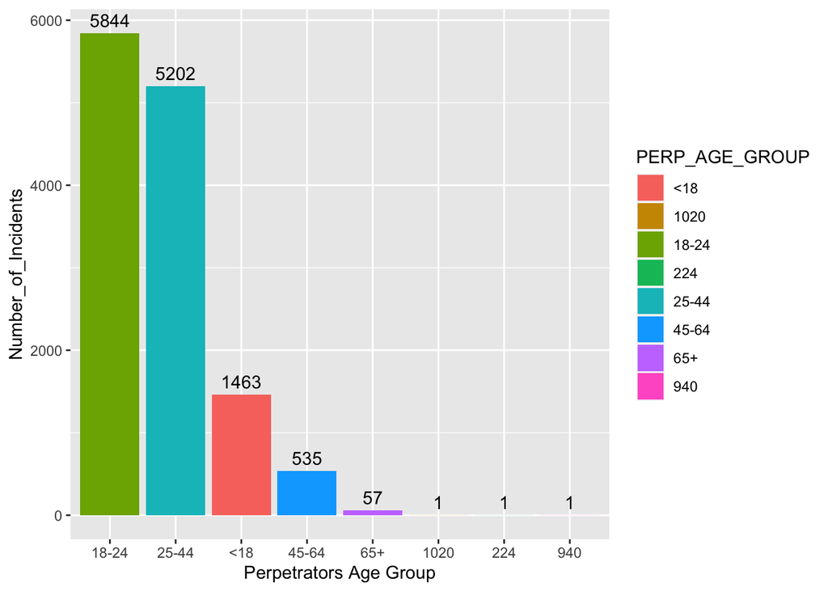

```r
nypddata_by_perp_age<-nypddata %>%
  group_by(PERP_AGE_GROUP) %>%
  summarise(count = n()) %>%
  rename('Number_of_Incidents'='count')

nypddata_by_perp_age %>%
  filter (PERP_AGE_GROUP!="UNKNOWN") %>%
  ggplot(aes(x=reorder(PERP_AGE_GROUP,-Number_of_Incidents),y=Number_of_Incidents,fill = PERP_AGE_GROUP))+
  geom_bar(stat = "identity") +
  geom_text(aes(label = Number_of_Incidents), vjust = -0.5)+
  labs(x="Perpetrators Age Group")
```

#### Analysis: It shows most of the victims are from the age group of 25-44. While most of the perpetrators are from the age group of 18-24.

### Visualization 4

#### Questions: What month of a year did the incidents mostly happen?

#### Visualization:

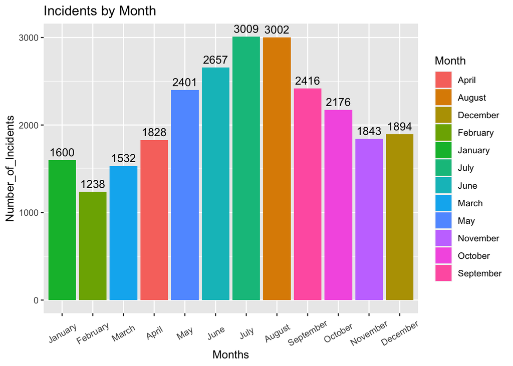

```r
nypddata_by_month<-nypddata %>%
  mutate(Month=month.name[as.integer(month(OCCUR_DATE))])%>%
  group_by(Month) %>%
  summarise(count = n()) %>%
  rename('Number_of_Incidents'='count')

ggplot(nypddata_by_month, aes(x = factor(Month, levels = month.name), y = Number_of_Incidents, fill = Month)) +
  geom_bar(stat = "identity") +
  geom_text(aes(label = Number_of_Incidents), vjust = -0.5) +
  labs(title = "Incidents by Month",x="Months")+
  theme(axis.text.x = element_text(angle = 30, vjust = 0.5))
```

#### Analysis: Most of the incidents happens during July and August. February has the lowest number of incidents during the year.